# 8. Modifikacije tabele i zapisivanje tabele u datoteku

U ovoj lekciji ćemo govoriti o:

1. dodavanju nove vrste ili kolone tabeli; i
2. zapisivanju tabele u datoteku.

## 8.1. Dodavanje nove vrste ili kolone tabeli

Ponekad je važno da vrednosti koje smo izračunali na osnovu podataka u tabeli (na primer, proseke ocena po učenicima) i sačuvamo u tabeli. Ako tabela nema za to predviđenu kolonu ili vrstu lako je možemo dodati!

Vratimo se ponovo na primer sa ocenama učenika koga smo videli na ranije:

```python
import pandas as pd
razred = [["Ana",     5, 3, 5, 2, 4, 5],
          ["Bojan",   5, 5, 5, 5, 5, 5],
          ["Vlada",   4, 5, 3, 4, 5, 4],
          ["Gordana", 5, 5, 5, 5, 5, 5],
          ["Dejan",   3, 4, 2, 3, 3, 4],
          ["Đorđe",   4, 5, 3, 4, 5, 4],
          ["Elena",   3, 3, 3, 4, 2, 3],
          ["Žaklina", 5, 5, 4, 5, 4, 5],
          ["Zoran",   4, 5, 4, 4, 3, 5],
          ["Ivana",   2, 2, 2, 2, 2, 5],
          ["Jasna",   3, 4, 5, 4, 5, 5]]
ocene = pd.DataFrame(razred)
ocene.columns=["Ime", "Informatika", "Engleski", "Matematika", "Fizika", "Hemija", "Likovno"]
ocene1 = ocene.set_index("Ime")
ocene1
```

| Ime | Informatika | Engleski | Matematika | Fizika | Hemija | Likovno |
| --- | --- | --- | --- | --- | --- | --- |
| Ana | 5 | 3 | 5 | 2 | 4 | 5 |
| Bojan | 5 | 5 | 5 | 5 | 5 | 5 |
| Vlada | 4 | 5 | 3 | 4 | 5 | 4 |
| Gordana | 5 | 5 | 5 | 5 | 5 | 5 |
| Dejan | 3 | 4 | 2 | 3 | 3 | 4 |
| Đorđe | 4 | 5 | 3 | 4 | 5 | 4 |
| Elena | 3 | 3 | 3 | 4 | 2 | 3 |
| Žaklina | 5 | 5 | 4 | 5 | 4 | 5 |
| Zoran | 4 | 5 | 4 | 4 | 3 | 5 |
| Ivana | 2 | 2 | 2 | 2 | 2 | 5 |
| Jasna | 3 | 4 | 5 | 4 | 5 | 5 |

Ovde smo prvo uvezli biblioteku *pandas* sa skraćenim imenom "pd", od liste podataka smo napravili tabelu, dali kolonama imena i indeksirali smo tabelu po imenu učenika.

Kao što smo ranije videli, lako možemo da izračunamo prosek ocena svakog učenika i da te podatke ispišemo. Međutim, ako želimo da proseke zapamtimo u tabeli, treba nam nova kolona. Nova kolona se tabeli dodaje tako što se prosto napiše:

```python
ocene1["ProsekUc"] = 0.0
```

Ako pokušamo da nepostojećoj koloni dodamo neku vrednost, sistem će sam na kraj tabele dodati novu kolonu i popuniti je navedenim vrednostima:

```python
ocene1
```

| Ime | Informatika | Engleski | Matematika | Fizika | Hemija | Likovno | ProsekUc |
| --- | --- | --- | --- | --- | --- | --- | --- |
| Ana | 5 | 3 | 5 | 2 | 4 | 5 | 0.0 |
| Bojan | 5 | 5 | 5 | 5 | 5 | 5 | 0.0 |
| Vlada | 4 | 5 | 3 | 4 | 5 | 4 | 0.0 |
| Gordana | 5 | 5 | 5 | 5 | 5 | 5 | 0.0 |
| Dejan | 3 | 4 | 2 | 3 | 3 | 4 | 0.0 |
| Đorđe | 4 | 5 | 3 | 4 | 5 | 4 | 0.0 |
| Elena | 3 | 3 | 3 | 4 | 2 | 3 | 0.0 |
| Žaklina | 5 | 5 | 4 | 5 | 4 | 5 | 0.0 |
| Zoran | 4 | 5 | 4 | 4 | 3 | 5 | 0.0 |
| Ivana | 2 | 2 | 2 | 2 | 2 | 5 | 0.0 |
| Jasna | 3 | 4 | 5 | 4 | 5 | 5 | 0.0 |

Sada ćemo u jednom *for*-ciklusu da prođemo kroz indeksnu kolonu tabele i da za svaki red tabele izračunamo prosek brojeva upisanih u kolone "Informatika"--"Likovno". (Ne smemo da računamo prosek celog reda, jer redovi sada sadrže i kolonu "ProsekUc" koja ne sme da se uključi u račun proseka!)

```python
for ucenik in ocene1.index:
    ocene1.loc[ucenik, "ProsekUc"] = ocene1.loc[ucenik, "Informatika":"Likovno"].mean()
```

Evo kako izgleda nova tabela:

```python
ocene1
```

| Ime | Informatika | Engleski | Matematika | Fizika | Hemija | Likovno | ProsekUc |
| --- | --- | --- | --- | --- | --- | --- | --- |
| Ana | 5 | 3 | 5 | 2 | 4 | 5 | 4.000000 |
| Bojan | 5 | 5 | 5 | 5 | 5 | 5 | 5.000000 |
| Vlada | 4 | 5 | 3 | 4 | 5 | 4 | 4.166667 |
| Gordana | 5 | 5 | 5 | 5 | 5 | 5 | 5.000000 |
| Dejan | 3 | 4 | 2 | 3 | 3 | 4 | 3.166667 |
| Đorđe | 4 | 5 | 3 | 4 | 5 | 4 | 4.166667 |
| Elena | 3 | 3 | 3 | 4 | 2 | 3 | 3.000000 |
| Žaklina | 5 | 5 | 4 | 5 | 4 | 5 | 4.666667 |
| Zoran | 4 | 5 | 4 | 4 | 3 | 5 | 4.166667 |
| Ivana | 2 | 2 | 2 | 2 | 2 | 5 | 2.500000 |
| Jasna | 3 | 4 | 5 | 4 | 5 | 5 | 4.333333 |

Da bismo izračunali prosečnu ocenu za svaki predmet, dodaćemo novu vrstu:

```python
ocene1.loc["ProsekPr"] = 0.0
ocene1
```

| Ime | Informatika | Engleski | Matematika | Fizika | Hemija | Likovno | ProsekUc |
| --- | --- | --- | --- | --- | --- | --- | --- |
| Ana | 5.0 | 3.0 | 5.0 | 2.0 | 4.0 | 5.0 | 4.000000 |
| Bojan | 5.0 | 5.0 | 5.0 | 5.0 | 5.0 | 5.0 | 5.000000 |
| Vlada | 4.0 | 5.0 | 3.0 | 4.0 | 5.0 | 4.0 | 4.166667 |
| Gordana | 5.0 | 5.0 | 5.0 | 5.0 | 5.0 | 5.0 | 5.000000 |
| Dejan | 3.0 | 4.0 | 2.0 | 3.0 | 3.0 | 4.0 | 3.166667 |
| Đorđe | 4.0 | 5.0 | 3.0 | 4.0 | 5.0 | 4.0 | 4.166667 |
| Elena | 3.0 | 3.0 | 3.0 | 4.0 | 2.0 | 3.0 | 3.000000 |
| Žaklina | 5.0 | 5.0 | 4.0 | 5.0 | 4.0 | 5.0 | 4.666667 |
| Zoran | 4.0 | 5.0 | 4.0 | 4.0 | 3.0 | 5.0 | 4.166667 |
| Ivana | 2.0 | 2.0 | 2.0 | 2.0 | 2.0 | 5.0 | 2.500000 |
| Jasna | 3.0 | 4.0 | 5.0 | 4.0 | 5.0 | 5.0 | 4.333333 |
| ProsekPr | 0.0 | 0.0 | 0.0 | 0.0 | 0.0 | 0.0 | 0.000000 |

Ovde treba da zastanemo za trenutak i da se podsetimo da se zapis oblika `ocene1["ProsekUc"]` odnosi na kolone tabele tako da će naredba

```
ocene1["ProsekUc"] = 0.0
```

dodati novu kolonu popunjenu nulama, dok se zapis `ocene1.loc["ProsekPr"]` odnosi na vrste tabele, pa će naredba

```
ocene1.loc["ProsekPr"] = 0.0
```

dodati novu vrstu popunjenu nulama (što se i desilo u primeru).

```python
for predmet in ocene1.columns:
    ocene1.loc["ProsekPr", predmet] = ocene1.loc["Ana":"Jasna", predmet].mean()
ocene1
```

| Ime | Informatika | Engleski | Matematika | Fizika | Hemija | Likovno | ProsekUc |
| --- | --- | --- | --- | --- | --- | --- | --- |
| Ana | 5.000000 | 3.000000 | 5.000000 | 2.000000 | 4.000000 | 5.000000 | 4.000000 |
| Bojan | 5.000000 | 5.000000 | 5.000000 | 5.000000 | 5.000000 | 5.000000 | 5.000000 |
| Vlada | 4.000000 | 5.000000 | 3.000000 | 4.000000 | 5.000000 | 4.000000 | 4.166667 |
| Gordana | 5.000000 | 5.000000 | 5.000000 | 5.000000 | 5.000000 | 5.000000 | 5.000000 |
| Dejan | 3.000000 | 4.000000 | 2.000000 | 3.000000 | 3.000000 | 4.000000 | 3.166667 |
| Đorđe | 4.000000 | 5.000000 | 3.000000 | 4.000000 | 5.000000 | 4.000000 | 4.166667 |
| Elena | 3.000000 | 3.000000 | 3.000000 | 4.000000 | 2.000000 | 3.000000 | 3.000000 |
| Žaklina | 5.000000 | 5.000000 | 4.000000 | 5.000000 | 4.000000 | 5.000000 | 4.666667 |
| Zoran | 4.000000 | 5.000000 | 4.000000 | 4.000000 | 3.000000 | 5.000000 | 4.166667 |
| Ivana | 2.000000 | 2.000000 | 2.000000 | 2.000000 | 2.000000 | 5.000000 | 2.500000 |
| Jasna | 3.000000 | 4.000000 | 5.000000 | 4.000000 | 5.000000 | 5.000000 | 4.333333 |
| ProsekPr | 3.909091 | 4.181818 | 3.727273 | 3.818182 | 3.909091 | 4.545455 | 4.015152 |

Evo još jednog primera. U folderu *podaci* se nalazi datoteka *StanovnistvoSrbije2017.csv* koja sadrži procenu broja stanovnika Republike Srbije po godinama na dan 31.12.2017. Prvi red tabele predstavlja zaglavlje tabele koje nam kaže da tabela ima tri kolone (Starost, Muško, Žensko). Prvo ćemo učitati tabelu i indeksirati je kolonom "Starost":

```python
stanovnistvo = pd.read_csv("podaci/StanovnistvoSrbije2017.csv")
stanovnistvo1 = stanovnistvo.set_index("Starost")
```

Sada ćemo uraditi malu demografsku analizu: izračunaćemo odnos broja muškaraca i žena po godinama starosti i prikazaćemo podatke linijskim dijagramom.

Prvo ćemo tabeli dodati novu kolonu "M/Ž" i u tu kolonu upisati izračunate odnose:

```python
stanovnistvo1["M/Ž"] = 0.0
for i in stanovnistvo1.index:
    stanovnistvo1.loc[i, "M/Ž"] = stanovnistvo1.loc[i, "Muško"] / stanovnistvo1.loc[i, "Žensko"]
```

Evo prvih nekoliko redova tabele:

```python
stanovnistvo1.head(10)
```

| Starost | Muško | Žensko | M/Ž |
| --- | --- | --- | --- |
| 0 | 33145 | 31444 | 1.054096 |
| 1 | 33252 | 31105 | 1.069024 |
| 2 | 33807 | 31475 | 1.074091 |
| 3 | 34076 | 31952 | 1.066475 |
| 4 | 33436 | 31643 | 1.056663 |
| 5 | 34278 | 32505 | 1.054545 |
| 6 | 33773 | 31523 | 1.071376 |
| 7 | 33892 | 32185 | 1.053037 |
| 8 | 34706 | 32396 | 1.071305 |
| 9 | 34519 | 32177 | 1.072785 |

Potom ćemo prikazati dijagram kome ćemo dodati liniju na visini 1.0 da bismo lakše uočili u kom trenutku broj muškaraca postaje manji od broja žena:

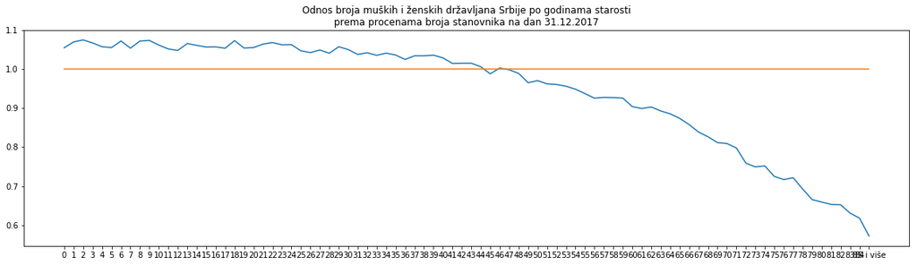

```python
import matplotlib.pyplot as plt
plt.figure(figsize=(20,5))
plt.plot(stanovnistvo1.index, stanovnistvo1["M/Ž"])
plt.plot(stanovnistvo1.index, [1.0] * len(stanovnistvo1.index))
plt.title("Odnos broja muških i ženskih državljana Srbije po godinama starosti\nprema procenama broja stanovnika na dan 31.12.2017")
plt.show()
plt.close()
```

## 8.2. Zapisivanje tabele u datoteku

Veoma je važno omogućiti da se podaci koji su učitani iz neke datoteke mogu, nakon obrade, ponovo upisati u datoteku. Da ova mogućnost ne postoji morali bismo svaki put iznova vršiti obradu podataka, što u nekim slučajevima može da bude veoma dugotrajan posao.

Tabela se upisuje u datoteku tipa *CSV* pozivom funkcije `to_csv` (engl. "u csv"). Na primer, tabelu `stanovnistvo1` smo modifikovali tako što smo joj dodali novu kolonu u koju smo upisali odnos broja muškaraca i žena po uzrastima. Ako želimo da tako modifikovanu tabelu sačuvamo pod novim imenom, to možemo učiniti ovako:

```python
stanovnistvo1.to_csv("podaci/StanovnistvoSrbije2017-Novo.csv", encoding="utf-8")
```

Evo primera. Sa linka

```
https://raw.githubusercontent.com/cs109/2014_data/master/countries.csv
```

ćemo učitati spisak država na svetu i zapisaćemo tu tabelu (bez ikakvih transformacija) u lokalnu datoteku *drzavesveta.csv* u folderu *podaci*:

```python
drzave = pd.read_csv("https://raw.githubusercontent.com/cs109/2014_data/master/countries.csv")
drzave.to_csv("podaci/drzavesveta.csv")
```

Ako sada iz nekog programa za uređivanje teksta (recimo, *Notepad*) pogledamo datoteku koju smo dobili zapisivanjem, videćemo da ona izgleda ovako (navedeno je samo prvih nekoliko redova):

```
,Country,Region
0,Algeria,AFRICA
1,Angola,AFRICA
2,Benin,AFRICA
3,Botswana,AFRICA
4,Burkina,AFRICA
5,Burundi,AFRICA
6,Cameroon,AFRICA
7,Cape Verde,AFRICA
8,Central African Republic,AFRICA
9,Chad,AFRICA
(itd)
```

Prilikom upisivanja podataka u tabelu Pajton je upisao i indeksnu kolonu. Kod tabele `stanovnistvo1` nam je to odgovaralo jer je tabela bila indeksirana kolonom "Starost". Ovde nam to, ipak, ne odgovara zato što indeksna kolona ne daje nikakvu važnu informaciju o podacima u tabeli. Ako želimo da upižemo tabelu u datoteku, ali tako da se indeksna kolona ne upisuje, možemo to uraditi ovako:

```python
drzave.to_csv("podaci/drzavesveta.csv", index=False)
```

Sada u datoteci piše:

```
Country,Region
Algeria,AFRICA
Angola,AFRICA
Benin,AFRICA
Botswana,AFRICA
Burkina,AFRICA
Burundi,AFRICA
Cameroon,AFRICA
Cape Verde,AFRICA
Central African Republic,AFRICA
Chad,AFRICA
(itd)
```

što smo i želeli.

## 8.3. Zadaci

Zadatke reši u Džupajteru.

**Zadatak 1.** Pogledaj pažljivo naredbe u sledećoj ćeliji, pa odgovori na pitanja:

```python
import pandas as pd

US = pd.read_html("https://simple.wikipedia.org/wiki/List_of_U.S._states", header=[0,1])[0]
US.to_csv("podaci/SAD.csv")
```

1. U kom formatu će biti zapisani podaci iz tabele "US"?
2. Da li će podaci biti zapisani lokalno, ili na neki udaljeni resurs?

**Zadatak 2.** Biolozi su do danas opisali oko dva miliona vrsta živih bića. Sva ona su podeljena u pet carstava. Njihov približan broj po carstvima je dat sledećom tabelom:

| Carstvo | Broj vrsta |
| --- | --- |
| Životinje | 1.400.000 |
| Biljke | 290.000 |
| Gljive | 100.000 |
| Protisti | 200.000 |
| Monere | 10.000 |

Dodaj novu vrstu tabeli koja se zove "Ukupno" i u nju unesi ukupan broj vrsta. Nemoj računati ručno, već primeni funkciju `sum` na odgovarajuću kolonu tabele.

**Zadatak 3.** U narednoj ćeliji dati su podaci o težini (u kilogramima) i dužini/visini (u centimetrima) jednog dečaka od njegovog šestog meseca pa do njegovih 6,5 godina.

```python
merenja   = ["6 mes", "1,5 god", "2,5 god", "3,5 god", "4,5 god", "5,5 god", "6,5 god"]
masaKG    = [5.9,     11.5,      14.8,      20.5,      22.0,      24.2,      29.0     ]
visinaCM  = [62.0,    84.0,      97.0,      115.0,     122.5,     131.5,     135.0    ]
```

Transponuj tabelu, tako transponobanoj tabeli dodaj novu kolonu, pa za svako merenje (što je sada vrsta u novoj, transponovanoj tabeli) izračunaj *BMI* (*body mass index*) po formuli:

$$\hbox{BMI} = \frac{\hbox{masa u kilogramima}}{(\hbox{visina u metrima})^2}$$

Dobijenu tabelu upiši u datoteku *BMI.csv* (obrati pažnju na to da u tabeli imaš podatke zapisane ćirilicom).

**Zadatak 4.** U sledećoj tabeli su prikazane najviše i najniže temperature (u Celzijusima) ikada izmerene na kontinentima:

| Kontinent: | Evropa | Azija | Afrika | Severna Amerika | Južna Amerika | Australija | Antarktik |
| --- | --- | --- | --- | --- | --- | --- | --- |
| Najviša zabeležena temp: | 48 | 54 | 55 | 56.7 | 48.9 | 50.7 | 19.8 |
| Najniža zabeležena temp: | -58.1 | -67.8 | -23.9 | -63 | -32.8 | -23 | -89.2 |

(Podaci su preuzeti sa stranice https://www.space.com/17816-earth-temperature.html). Dodaj novi red ovoj tabeli pa u njega upiši maksimalni temperaturni raspon za svaki kontinent, koji se dobija kada se od najviše zabeležene temperature oduzme najniža zabeležena temperatura.

**Zadatak 5.** U folderu *podaci* se nalazi datoteka *StanovnistvoSrbije2017.csv* (koja ima zaglavlje). Tabela ima tri kolone koje se zovu "Starost", "Muško" i "Žensko".

*(a)* Učitaj datoteku u strukturu podataka *DataFrame* i indeksiraj tabelu kolonom "Starost".

*(b)* Dodaj tabeli novu kolonu "UkupnoSt" i onda izračunaj i u tu kolonu upiši podatak o tome koliki je ukupan procenjeni broj stanovnika po starosti. Prikaži ukupan procenjeni broj stanovnika po starosti linijskim dijagramom.

*(v)* Dodaj tabeli novu vrstu "UkupnoPol" i onda izračunaj i u tu vrstu upiši podatak o tome koliki je ukupan procenjeni broj stanovnika po polu. Prikaži ukupan procenjeni broj stanovnika po polu sektorskim dijagramom.

*(g)* Na ovaj način izmenjenu tabelu snimi u datoteku *podaci.csv* (obrati pažnju na to da u tabeli imaš podatke zapisane ćirilicom).

**Zadatak 6.** Evo troškova života jedne porodice tokom jedne godine, po mesecima (svi iznosi su predstavljeni u dinarima):

| Stavka | Jan | Feb | Mar | Apr | Maj | Jun | Jul | Avg | Sep | Okt | Nov | Dec |
| --- | --- | --- | --- | --- | --- | --- | --- | --- | --- | --- | --- | --- |
| Stanarina | 8.251 | 8.436 | 8.524 | 8.388 | 8.241 | 8.196 | 8.004 | 7.996 | 7.991 | 8.015 | 8.353 | 8.456 |
| Struja | 4.321 | 4.530 | 4.115 | 3.990 | 3.985 | 3.726 | 3.351 | 3.289 | 3.295 | 3.485 | 3.826 | 3.834 |
| Telefon (fiksni) | 1.425 | 1.538 | 1.623 | 1.489 | 1.521 | 1.485 | 1.491 | 1.399 | 1.467 | 1.531 | 1.410 | 1.385 |
| Telefon (mobilni) | 2.181 | 2.235 | 2.073 | 1.951 | 1.989 | 1.945 | 3.017 | 2.638 | 2.171 | 1.831 | 1.926 | 1.833 |
| TV i internet | 2.399 | 2.399 | 2.399 | 2.399 | 2.399 | 2.399 | 2.399 | 2.399 | 2.399 | 2.399 | 2.399 | 2.399 |
| Prevoz | 1.830 | 1.830 | 1.830 | 1.830 | 1.950 | 1.950 | 1.450 | 1.450 | 1.950 | 1.950 | 2.050 | 2.050 |
| Hrana | 23.250 | 23.780 | 24.019 | 24.117 | 24.389 | 24.571 | 24.736 | 24.951 | 25.111 | 25.389 | 25.531 | 25.923 |
| Ostalo | 4.500 | 3.700 | 5.100 | 3.500 | 2.750 | 4.250 | 7.320 | 8.250 | 3.270 | 4.290 | 3.200 | 8.390 |

U ćeliji ispod su isti podaci predstavljeni listom:

```python
troskovi = [
  ["Stanarina", 8251, 8436, 8524, 8388, 8241, 8196, 8004, 7996, 7991, 8015, 8353, 8456],
  ["Struja", 4321, 4530, 4115, 3990, 3985, 3726, 3351, 3289, 3295, 3485, 3826, 3834],
  ["Telefon (fiksni)", 1425, 1538, 1623, 1489, 1521, 1485, 1491, 1399, 1467, 1531, 1410, 1385],
  ["Telefon (mobilni)", 2181, 2235, 2073, 1951, 1989, 1945, 3017, 2638, 2171, 1831, 1926, 1833],
  ["TV i internet", 2399, 2399, 2399, 2399, 2399, 2399, 2399, 2399, 2399, 2399, 2399, 2399 ],
  ["Prevoz", 1830, 1830, 1830, 1830, 1950, 1950, 1450, 1450, 1950, 1950, 2050, 2050],
  ["Hrana", 23250, 23780, 24019, 24117, 24389, 24571, 24736, 24951, 25111, 25389, 25531, 25923],
  ["Ostalo", 4500, 3700, 5100, 3500, 2750, 4250, 7320, 8250, 3270, 4290, 3200, 8390]
]
```

*(a)* Predstavi tabelu strukturom *DataFrame*. Indeksiraj tabelu.

*(b)* Dodaj tabeli novu vrstu "Ukupno" pa u nju unesi ukupne troškove ove porodice po mesecima (koliko je porodica ukupno potrošila u januaru, koliko u februaru itd).

*(v)* Dodaj tabeli novu kolonu "Prosečno" pa u nju unesi prosečnu potrošnju ove porodice po stavkama (koliko je porodica prosečno potrošila na stanarinu, koliko na struju, itd).

*(g)* Dobijenu tabelu upiši u datoteku *Troskovi.csv* vodeći računa o tome da u tabeli ima podataka koji su zapisani ćirilicom.